# R Charting: Solutions

# Solutions: Section 1

# 1.1

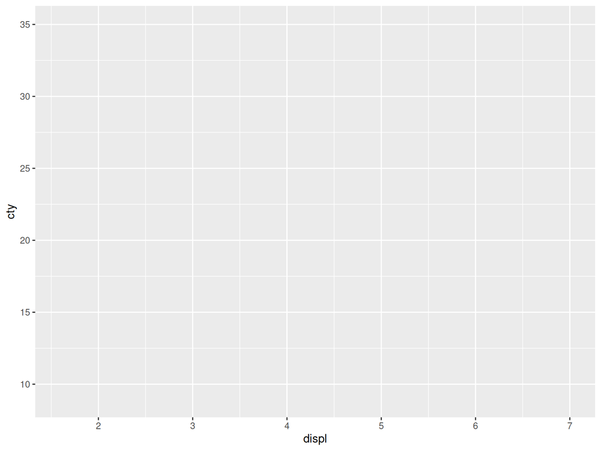

```r
ggplot2::ggplot(mpg, aes(x = displ, y = cty))
```

# 1.2

```r
?mpg
```

# 1.3

Make a scatter plot of `hwy` vs. `cty`

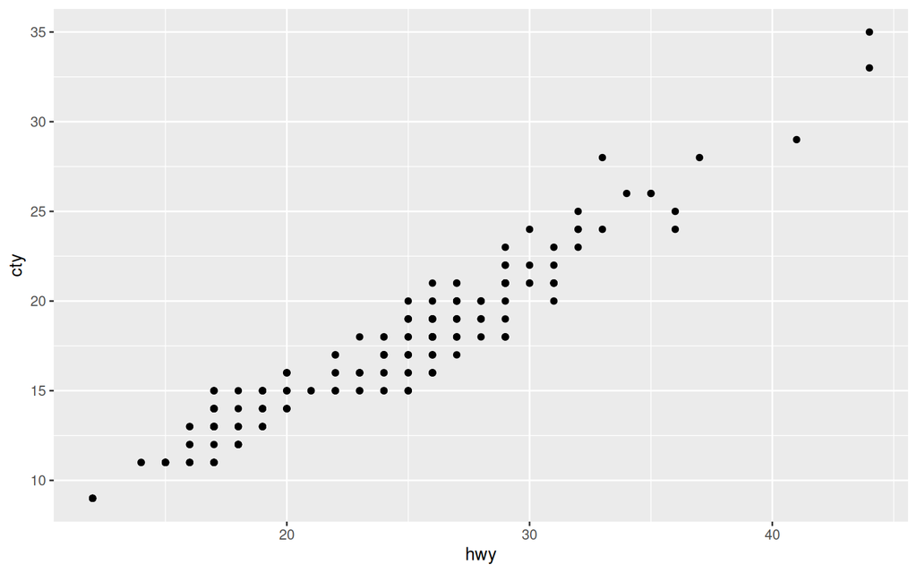

```r
ggplot2::ggplot(data = mpg, aes(x = hwy, y = cty)) +
  ggplot2::geom_point()
```

# 1.4

Make a scatter plot of urban fuel consumption vs engine size (displacement).

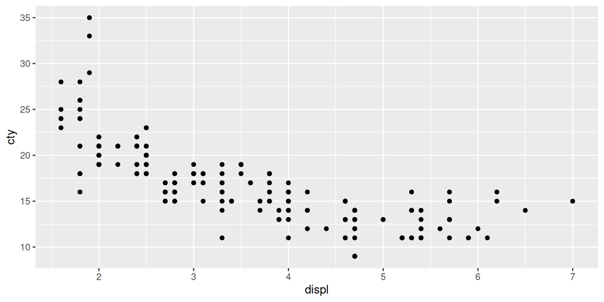

```r
ggplot2::ggplot(data = mpg, aes(x = displ, y = cty)) +
  ggplot2::geom_point()
```

# Solutions: Section 2

# 2.1

What’s wrong with this code? Why aren’t the points blue?

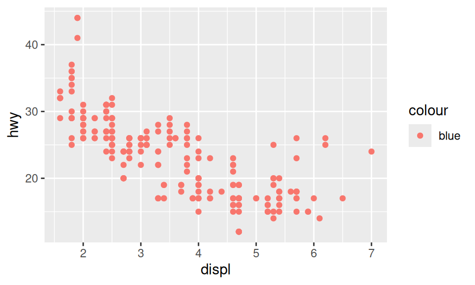

```r
ggplot2::ggplot(data = mpg, aes(x = displ, y = hwy, colour = "blue")) +
  ggplot2::geom_point()
```

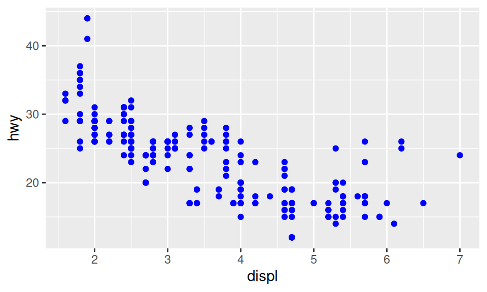

```r
ggplot2::ggplot(data = mpg, aes(x = displ, y = hwy)) +
  ggplot2::geom_point(colour = "blue")
```

# 2.2

Map a continuous variable to `colour`, `size` and `shape`. How do these aesthetics behave differently for categorical vs. continuous variables? Hint: use `dplyr::glimpse(mpg)` to identify variable types.

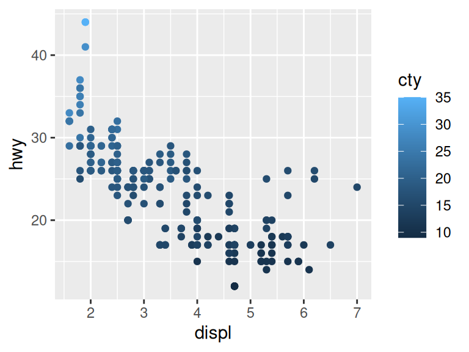

```r
ggplot2::ggplot(data = mpg, aes(x = displ, y = hwy, colour = cty)) +
  ggplot2::geom_point()
```

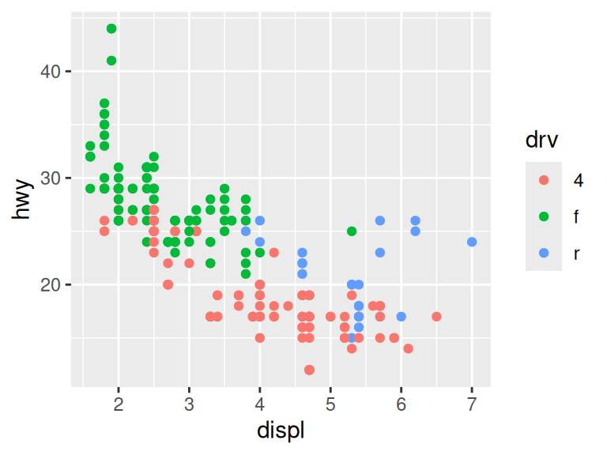

```r
ggplot2::ggplot(data = mpg, aes(x = displ, y = hwy, colour = drv)) +
  ggplot2::geom_point()
```

# 2.3

What happens if you map the same variable to multiple aesthetics?

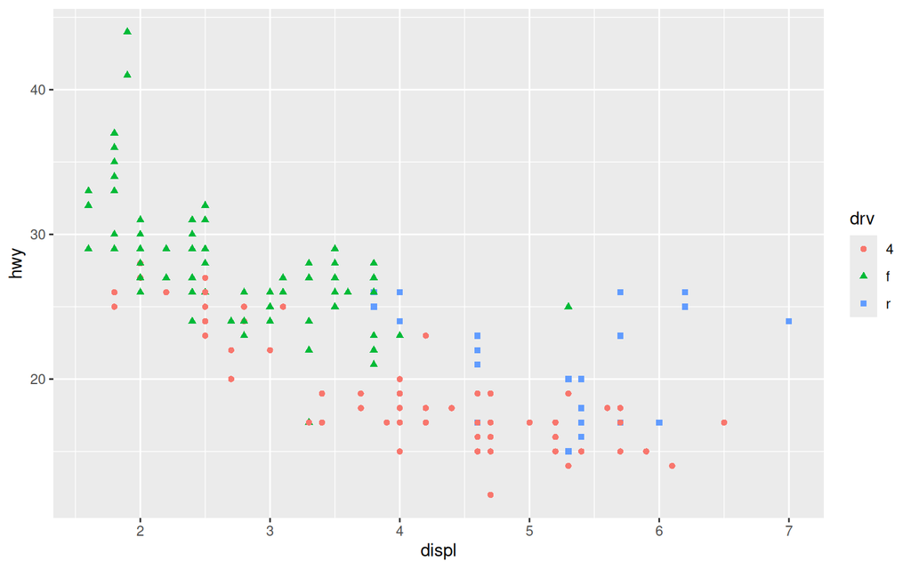

```r
ggplot2::ggplot(data = mpg, aes(x = displ, y = hwy, colour = drv, shape = drv)) +
  ggplot2::geom_point()
```

# 2.4

What happens if you map an aesthetic to something other than a variable name, like a Boolean statement `aes(colour = displ < 5)`

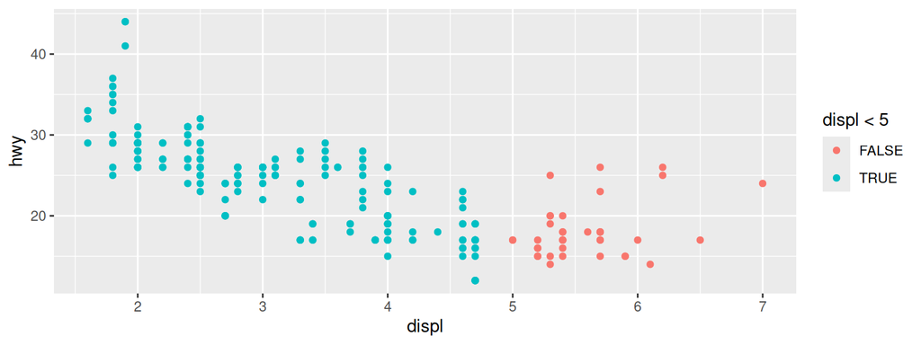

```r
ggplot2::ggplot(data = mpg, aes(x = displ, y = hwy, colour = displ < 5)) +
  ggplot2::geom_point()
```

# Solutions: Section 3

# 3.1

Using the `mpg` dataset create a histogram of `cty`. What impact do different values for the `bins` argument have?

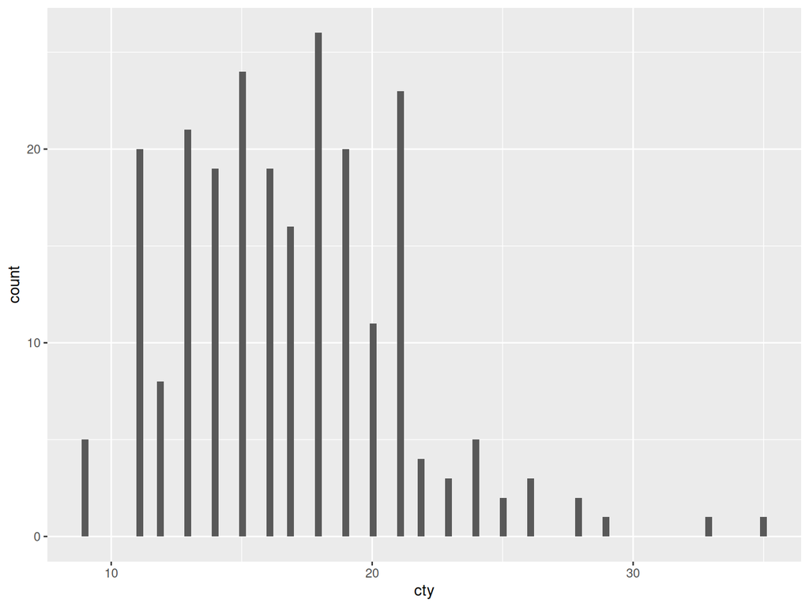

```r
ggplot2::ggplot(data = mpg, aes(x = cty)) +
  ggplot2::geom_histogram(bins = 100)
```

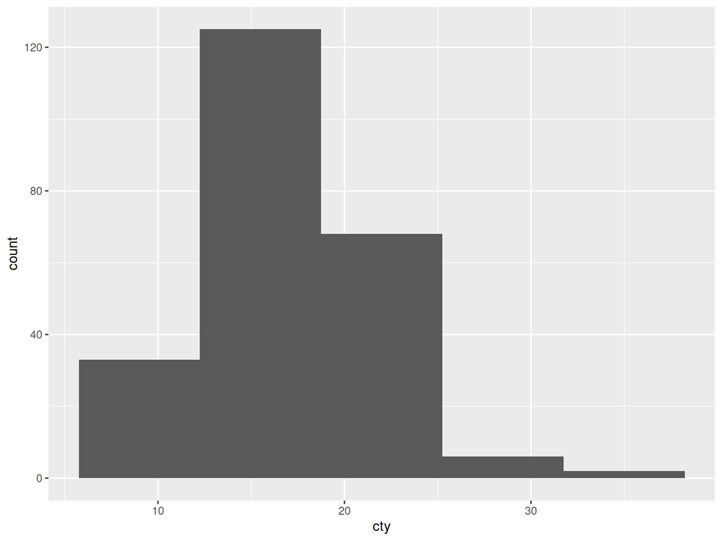

```r
ggplot2::ggplot(data = mpg, aes(x = cty)) +
  ggplot2::geom_histogram(bins = 5)
```

# 3.2

Make a density plot of `cty` by `drv`. Use the `alpha` argument to make the overlapping regions visible.

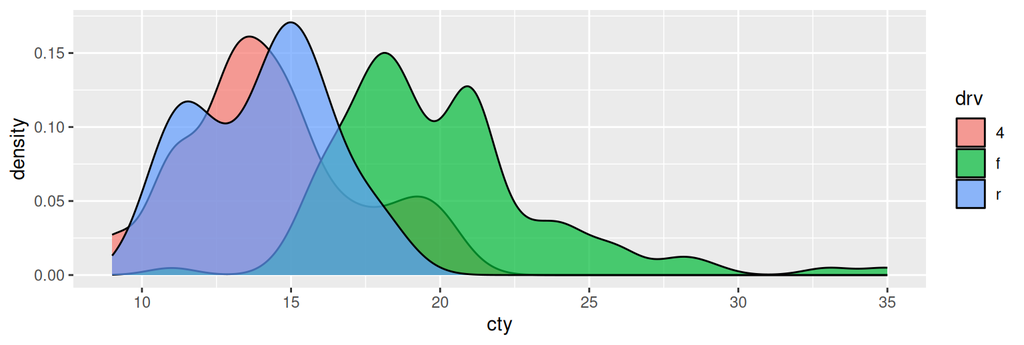

```r
ggplot2::ggplot(data = mpg, aes(x = cty, fill = drv)) +
  ggplot2::geom_density(alpha = 0.7)
```

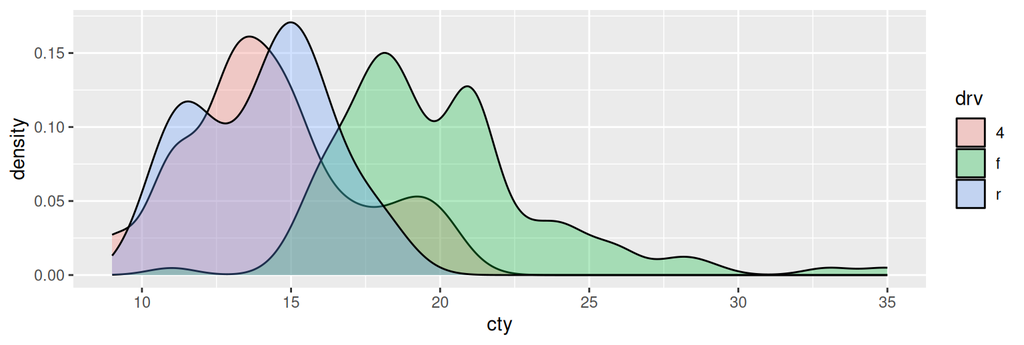

```r
ggplot2::ggplot(data = mpg, aes(x = cty, fill = drv)) +
  ggplot2::geom_density(alpha = 0.3)
```

# 3.3

Recreate the US unemployed population line graph. Add another line to show the total population.

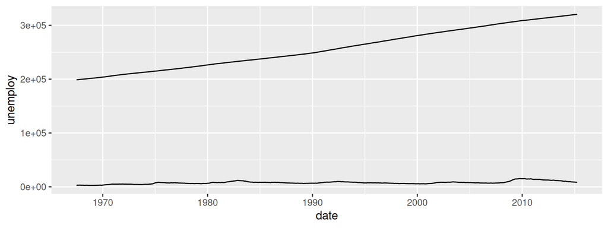

```r
ggplot2::economics |>
  ggplot2::ggplot(aes(x = date, y = unemploy)) +
  ggplot2::geom_line() +
  ggplot2::geom_line(aes(x = date, y = pop))
```

# Solutions: Section 4

# 4.1

Create a basic scatter plot showing highway fuel efficiency vs city fuel efficiency. Add a theme_minimal; and colour the points based on the number of cylinders the car has.

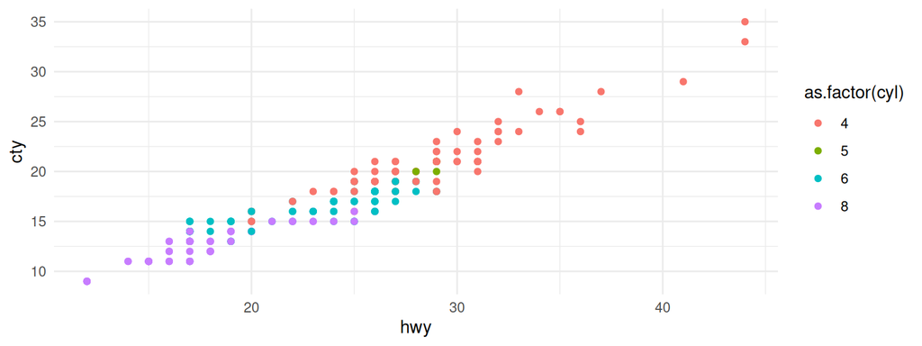

```r
ggplot2::ggplot(data = mpg) +
  ggplot2::geom_point(mapping = aes(x = hwy, y = cty, colour = as.factor(cyl))) +
  ggplot2::theme_minimal()
```

# 4.2

Change the title and axis labels to something sensible based on what the chart is showing.

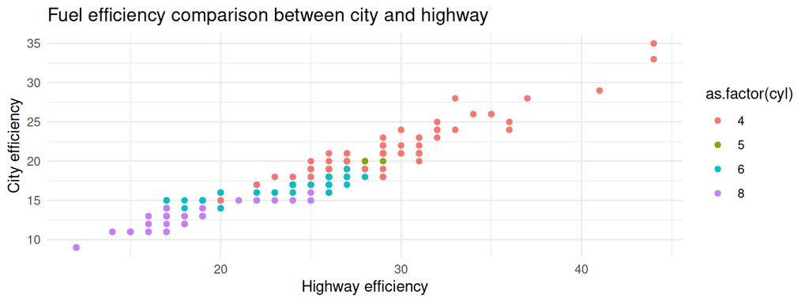

```r
ggplot2::ggplot(data = mpg) +
  ggplot2::geom_point(mapping = aes(x = hwy, y = cty, colour = as.factor(cyl))) +
  ggplot2::theme_minimal() +
  ggplot2::labs(title = "Fuel efficiency comparison between city and highway",
                x = "Highway efficiency",
                y = "City efficiency")
```

# 4.3

Create a custom theme changing: major gridlines to grey, dashed; removing minor gridlines; x and y axis text to black, pt 10, italic; move the legend position to the bottom of the plot.

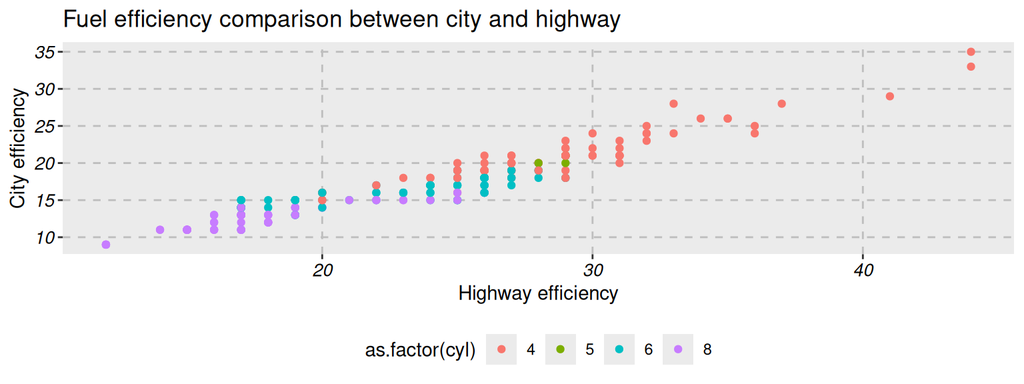

```r
ggplot2::ggplot(data = mpg) +
  ggplot2::geom_point(mapping = aes(x = hwy, y = cty, colour = as.factor(cyl))) +
  ggplot2::labs(title = "Fuel efficiency comparison between city and highway",
                x = "Highway efficiency",
                y = "City efficiency") +
  ggplot2::theme(panel.grid.major = ggplot2::element_line(colour = "grey", linetype = "dashed"),
                 panel.grid.minor = ggplot2::element_blank(),
                 axis.text = ggplot2::element_text(colour = "black", size = 10, face = "italic"),
                 legend.position = "bottom")
```

# 4.4

Instead of the custom theme, use the gss theme from `mojchart` and one of the built-in colour schemes.

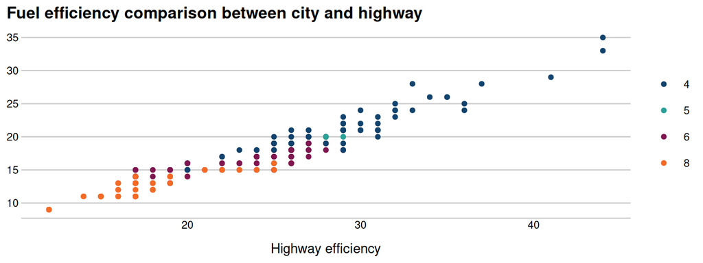

```r
ggplot2::ggplot(data = mpg) +
  ggplot2::geom_point(mapping = aes(x = hwy, y = cty, colour = as.factor(cyl))) +
  ggplot2::labs(title = "Fuel efficiency comparison between city and highway",
                x = "Highway efficiency",
                y = "City efficiency") +
  mojchart::scale_colour_moj(n = 4, palette = "govanal_bars") +
  mojchart::theme_gss(xlabel = TRUE)
```

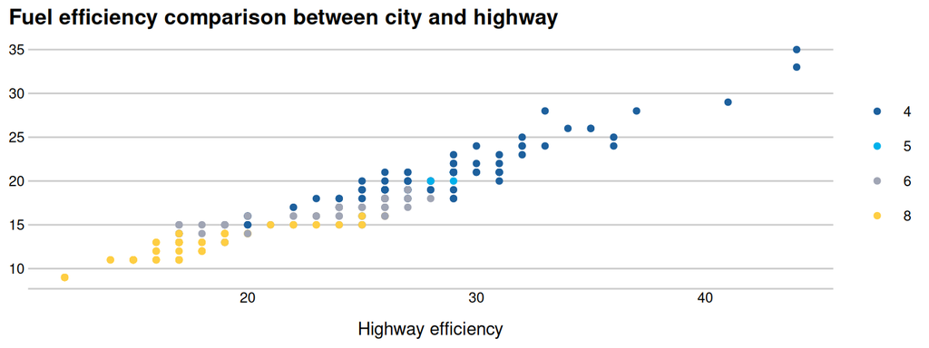

```r
ggplot2::ggplot(data = mpg) +
  ggplot2::geom_point(mapping = aes(x = hwy, y = cty, colour = as.factor(cyl))) +
  ggplot2::labs(title = "Fuel efficiency comparison between city and highway",
                x = "Highway efficiency",
                y = "City efficiency") +
  mojchart::scale_colour_moj(n = 4) +
  mojchart::theme_gss(xlabel = TRUE)
```